# R Notebook

Exercise 2: Residual Normal QQ-Plot a - The Plot Obtain the normal probability QQ-Plot of the residuals. b - Normality Do the residuals look normal?

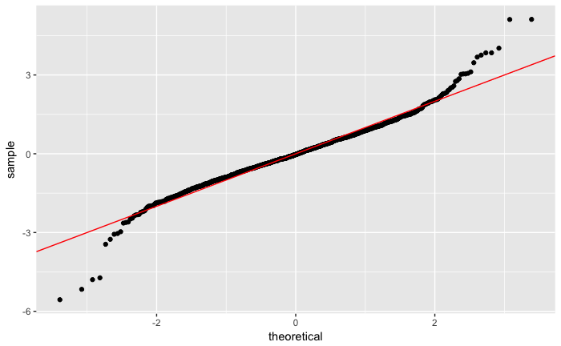

```r
library("ggplot2")
mod <- fortify(gg)
plot3 <- qplot(sample =.stdresid, data = gg, geom = "qq") + geom_abline(col="red")
grid.arrange(plot3, nrow = 1)
```

Exercise 3: Composite goodness-of-fit plots We use the following code to produce the composite goodness-of-fit plots. (g is the fitted model object.)

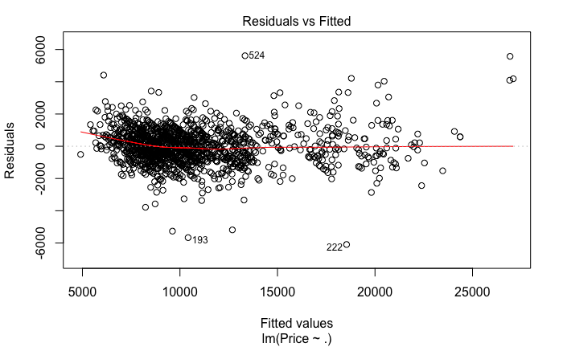

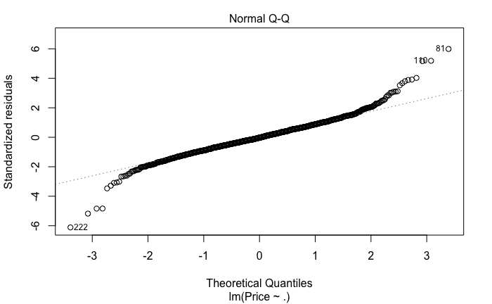

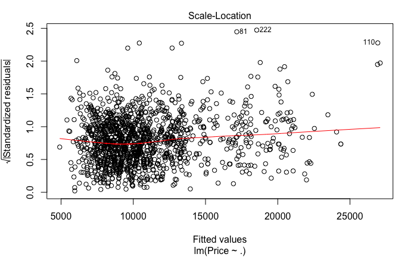

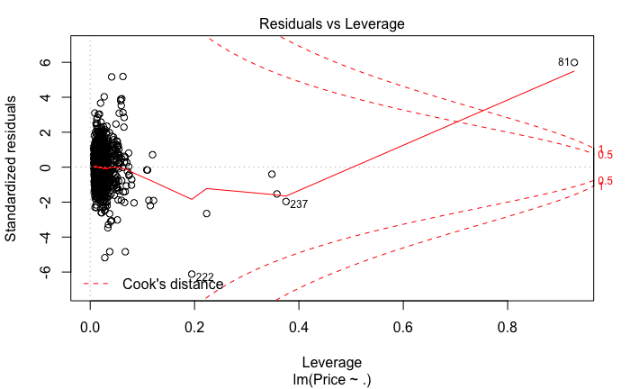

```r
plot(g)
```

Question a - Obtain the composite goodness-of-fit plots Obtain the composite goodness-of-fit plots for the fitted model. What plots involve the residuals? Do the Residuals vs Fitted Plot and the Normal QQ-Plot look about the same as those obtained earlier?

Question b - Outliers We examine the Residuals vs Leverage Plot in the composite goodness-of-fit plots. Outliers points will be identified by their row name. Are there any outliers? If so, what are their row names.